# Ally Auto Receivables Monthly Update

#### Ally Auto Receivables Trust 2019-1

##### Summary

Ending number of receivables: 50,013

Remaining principal balance across all receivables: $670,144,010

##### Current Period Distribution

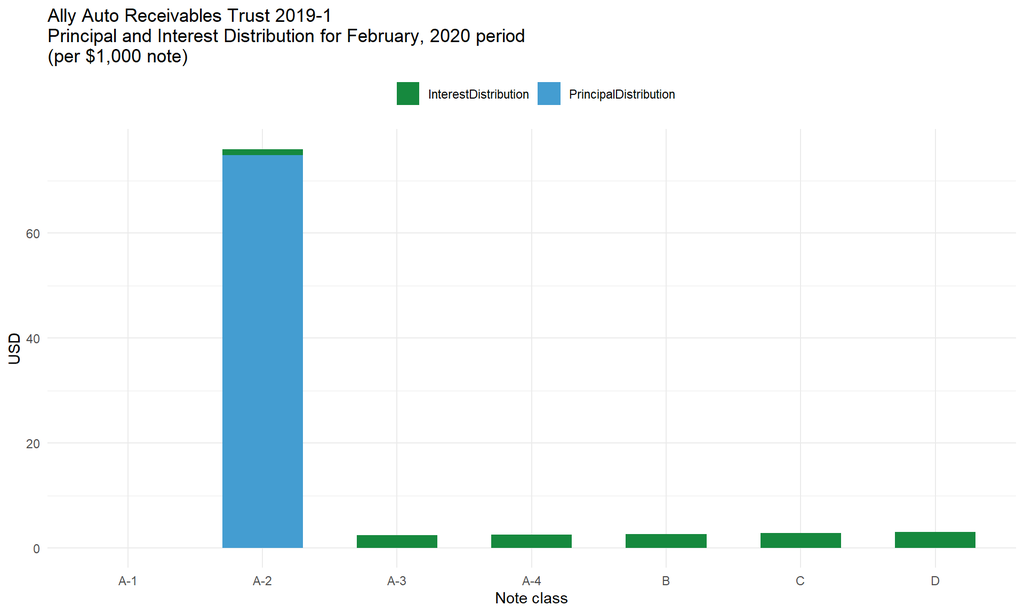

|  | deal | class | PrincipalDistribution | InterestDistribution |
| --- | --- | --- | --- | --- |
| 1 | Ally Auto Receivables Trust 2019-1 | A-1 | 0 | 0 |
| 2 | Ally Auto Receivables Trust 2019-1 | A-2 | 74.8061358536585 | 1.16643699186992 |
| 3 | Ally Auto Receivables Trust 2019-1 | A-3 | 0 | 2.425 |
| 4 | Ally Auto Receivables Trust 2019-1 | A-4 | 0 | 2.5166667109458 |
| 5 | Ally Auto Receivables Trust 2019-1 | B | 0 | 2.69166651785714 |
| 6 | Ally Auto Receivables Trust 2019-1 | C | 0 | 2.85833352534562 |
| 7 | Ally Auto Receivables Trust 2019-1 | D | 0 | 3.0583336038961 |

##### Cumulative Distribution

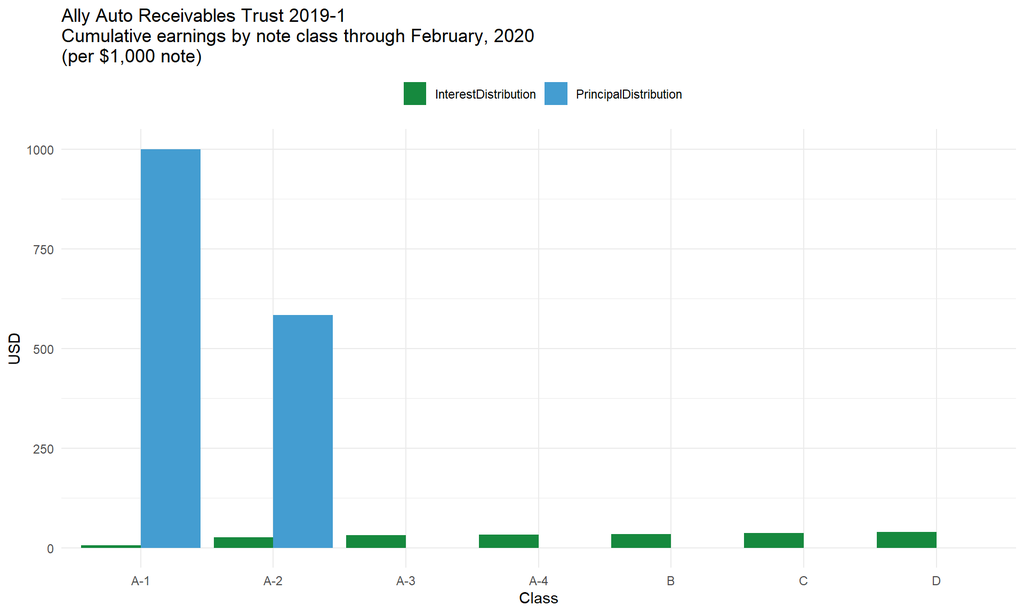

|  | deal | class | PrincipalDistribution | InterestDistribution |
| --- | --- | --- | --- | --- |
| 1 | Ally Auto Receivables Trust 2019-1 | A-1 | 1000 | 6.75465803278689 |
| 2 | Ally Auto Receivables Trust 2019-1 | A-2 | 583.674766368564 | 26.5385874525745 |
| 3 | Ally Auto Receivables Trust 2019-1 | A-3 | 0 | 31.6866666666667 |
| 4 | Ally Auto Receivables Trust 2019-1 | A-4 | 0 | 32.8844450053135 |
| 5 | Ally Auto Receivables Trust 2019-1 | B | 0 | 35.171109375 |
| 6 | Ally Auto Receivables Trust 2019-1 | C | 0 | 37.3488911290323 |
| 7 | Ally Auto Receivables Trust 2019-1 | D | 0 | 39.9622256493506 |

##### Forecast

Forecasted principal balances are based on a forecasted total amount distributed to interest and principal balances in future terms. These values are calculated using an ETS time series forecasting model. It uses the historic values as input to create the forecasted values (see bottom chart).

Remaining note principal balances are calculated in each period by subtracting the forecasted dsitribution amount from remaining note principal balances according to note seniority. In each period, the interest distribution amount is first calculated and subtracted from the forecasted distribution amount before applying the remaining distribution amount to the note principal balances for the next period.

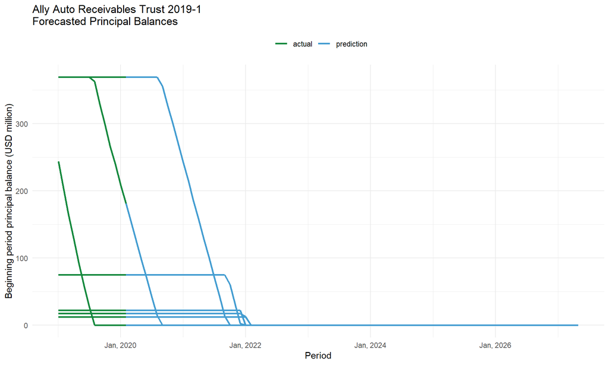

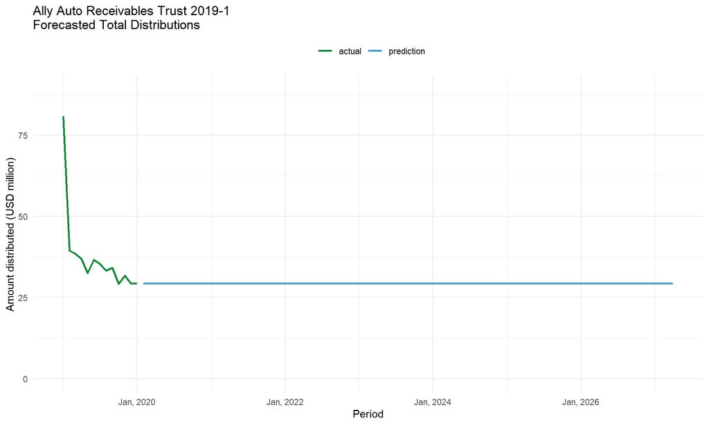

#### Ally Auto Receivables Trust 2019-2

##### Summary

Ending number of receivables: 54,183

Remaining principal balance across all receivables: $778,070,144

##### Current Period Distribution

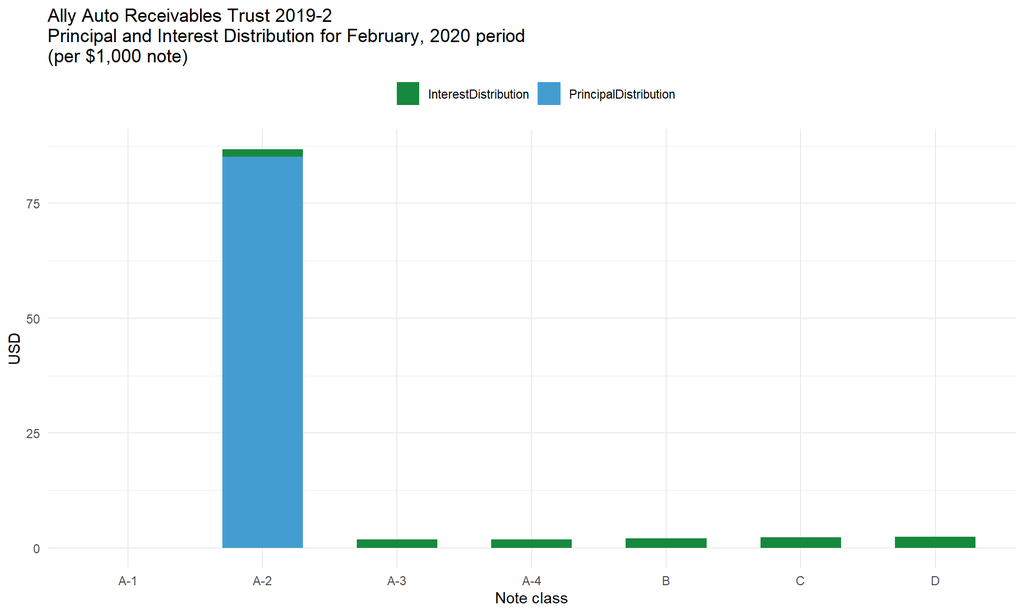

|  | deal | class | PrincipalDistribution | InterestDistribution |
| --- | --- | --- | --- | --- |
| 1 | Ally Auto Receivables Trust 2019-2 | A-1 | 0 | 0 |
| 2 | Ally Auto Receivables Trust 2019-2 | A-2 | 85.1844254038997 | 1.61390142061281 |
| 3 | Ally Auto Receivables Trust 2019-2 | A-3 | 0 | 1.85833334261838 |
| 4 | Ally Auto Receivables Trust 2019-2 | A-4 | 0 | 1.88333333333333 |
| 5 | Ally Auto Receivables Trust 2019-2 | B | 0 | 2.11666681534344 |
| 6 | Ally Auto Receivables Trust 2019-2 | C | 0 | 2.283333141542 |
| 7 | Ally Auto Receivables Trust 2019-2 | D | 0 | 2.49166666666667 |

##### Cumulative Distribution

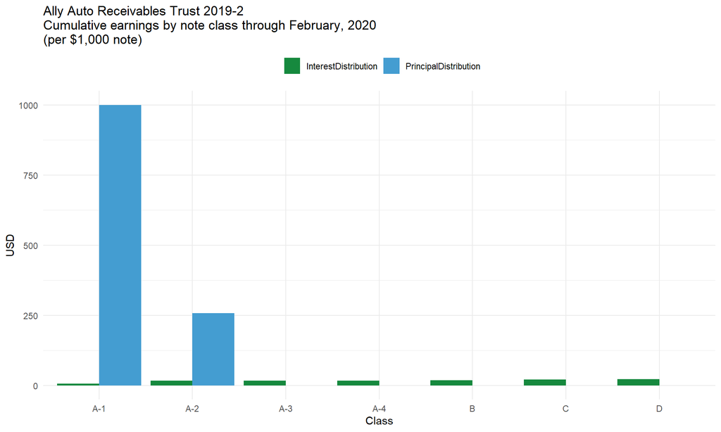

|  | deal | class | PrincipalDistribution | InterestDistribution |
| --- | --- | --- | --- | --- |
| 1 | Ally Auto Receivables Trust 2019-2 | A-1 | 1000 | 6.35465865384615 |
| 2 | Ally Auto Receivables Trust 2019-2 | A-2 | 257.542674651811 | 17.3042764066852 |
| 3 | Ally Auto Receivables Trust 2019-2 | A-3 | 0 | 16.9727778551532 |
| 4 | Ally Auto Receivables Trust 2019-2 | A-4 | 0 | 17.2011110695587 |
| 5 | Ally Auto Receivables Trust 2019-2 | B | 0 | 19.3322234611954 |
| 6 | Ally Auto Receivables Trust 2019-2 | C | 0 | 20.8544430379747 |
| 7 | Ally Auto Receivables Trust 2019-2 | D | 0 | 22.7572222222222 |

##### Forecast

Forecasted principal balances are based on a forecasted total amount distributed to interest and principal balances in future terms. These values are calculated using an ETS time series forecasting model. It uses the historic values as input to create the forecasted values (see bottom chart).

Remaining note principal balances are calculated in each period by subtracting the forecasted dsitribution amount from remaining note principal balances according to note seniority. In each period, the interest distribution amount is first calculated and subtracted from the forecasted distribution amount before applying the remaining distribution amount to the note principal balances for the next period.

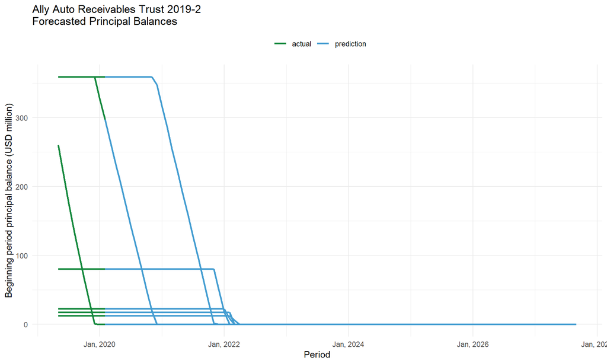

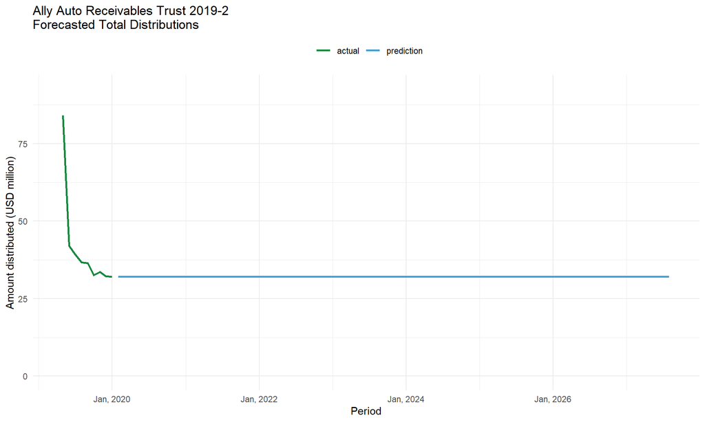

#### Ally Auto Receivables Trust 2019-3

##### Summary

Ending number of receivables: 58,578

Remaining principal balance across all receivables: $867,222,350

##### Current Period Distribution

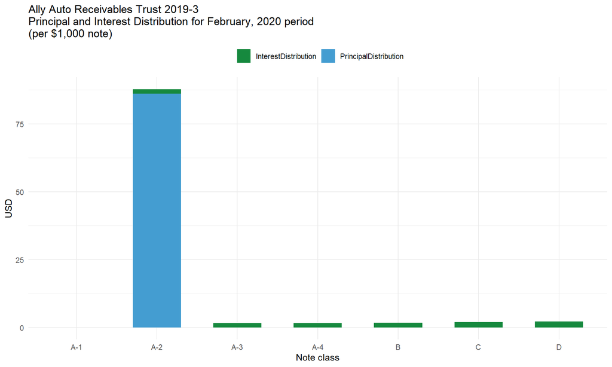

|  | deal | class | PrincipalDistribution | InterestDistribution |
| --- | --- | --- | --- | --- |
| 1 | Ally Auto Receivables Trust 2019-3 | A-1 | 0 | 0 |
| 2 | Ally Auto Receivables Trust 2019-3 | A-2 | 86.106357974026 | 1.70708150649351 |
| 3 | Ally Auto Receivables Trust 2019-3 | A-3 | 0 | 1.60833332432432 |
| 4 | Ally Auto Receivables Trust 2019-3 | A-4 | 0 | 1.63333328901888 |
| 5 | Ally Auto Receivables Trust 2019-3 | B | 0 | 1.81666652506372 |
| 6 | Ally Auto Receivables Trust 2019-3 | C | 0 | 1.98333333333333 |
| 7 | Ally Auto Receivables Trust 2019-3 | D | 0 | 2.19166643788607 |

##### Cumulative Distribution

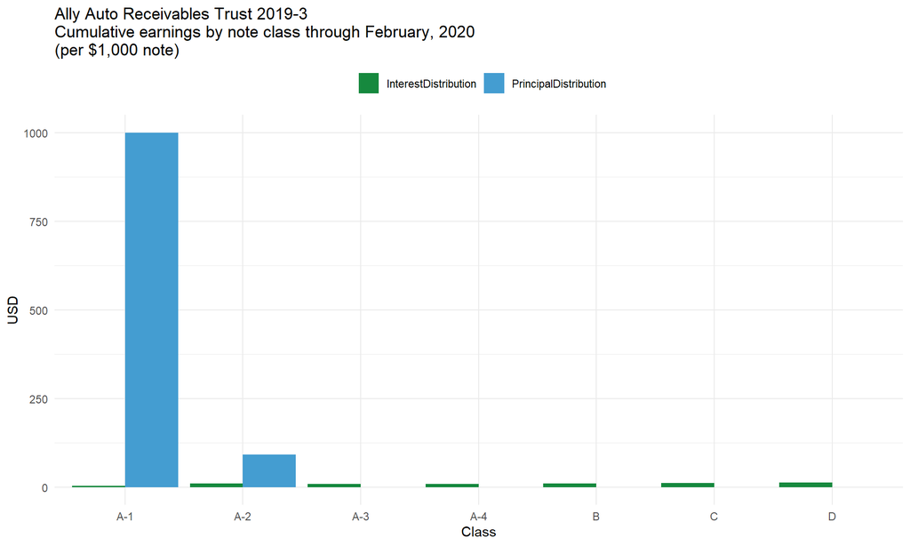

|  | deal | class | PrincipalDistribution | InterestDistribution |
| --- | --- | --- | --- | --- |
| 1 | Ally Auto Receivables Trust 2019-3 | A-1 | 1000 | 4.29255131578947 |
| 2 | Ally Auto Receivables Trust 2019-3 | A-2 | 91.6899485974026 | 10.1759704415584 |
| 3 | Ally Auto Receivables Trust 2019-3 | A-3 | 0 | 9.54277772972973 |
| 4 | Ally Auto Receivables Trust 2019-3 | A-4 | 0 | 9.69111087476735 |
| 5 | Ally Auto Receivables Trust 2019-3 | B | 0 | 10.7788882752761 |
| 6 | Ally Auto Receivables Trust 2019-3 | C | 0 | 11.7677777777778 |
| 7 | Ally Auto Receivables Trust 2019-3 | D | 0 | 13.0038874399451 |

##### Forecast

Forecasted principal balances are based on a forecasted total amount distributed to interest and principal balances in future terms. These values are calculated using an ETS time series forecasting model. It uses the historic values as input to create the forecasted values (see bottom chart).

Remaining note principal balances are calculated in each period by subtracting the forecasted dsitribution amount from remaining note principal balances according to note seniority. In each period, the interest distribution amount is first calculated and subtracted from the forecasted distribution amount before applying the remaining distribution amount to the note principal balances for the next period.

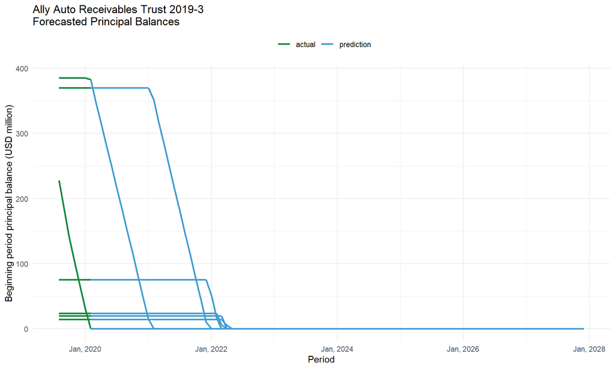

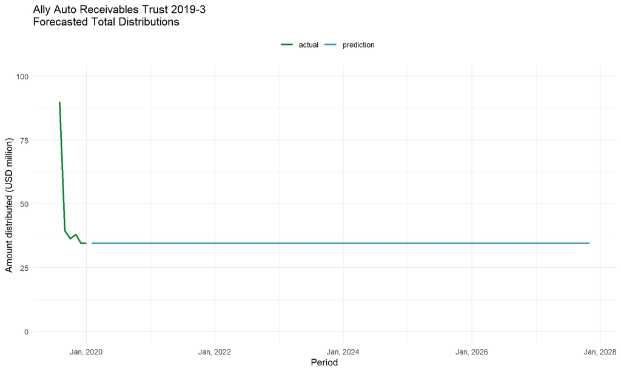

#### Ally Auto Receivables Trust 2019-4

##### Summary

Ending number of receivables: 61,457

Remaining principal balance across all receivables: $891,350,683

##### Current Period Distribution

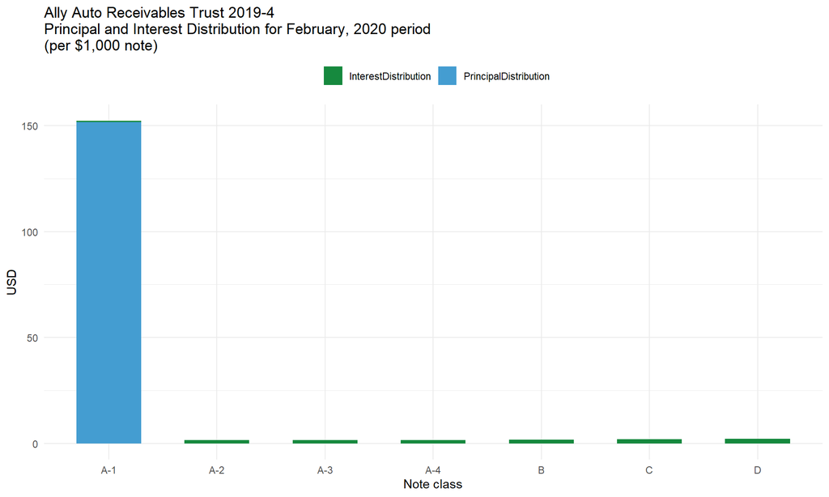

|  | deal | class | PrincipalDistribution | InterestDistribution |
| --- | --- | --- | --- | --- |
| 1 | Ally Auto Receivables Trust 2019-4 | A-1 | 151.601806071429 | 0.671275317460317 |
| 2 | Ally Auto Receivables Trust 2019-4 | A-2 | 0 | 1.60833333333333 |
| 3 | Ally Auto Receivables Trust 2019-4 | A-3 | 0 | 1.53333333333333 |
| 4 | Ally Auto Receivables Trust 2019-4 | A-4 | 0 | 1.6 |
| 5 | Ally Auto Receivables Trust 2019-4 | B | 0 | 1.78333318223028 |
| 6 | Ally Auto Receivables Trust 2019-4 | C | 0 | 1.95 |
| 7 | Ally Auto Receivables Trust 2019-4 | D | 0 | 2.15833308931186 |

##### Cumulative Distribution

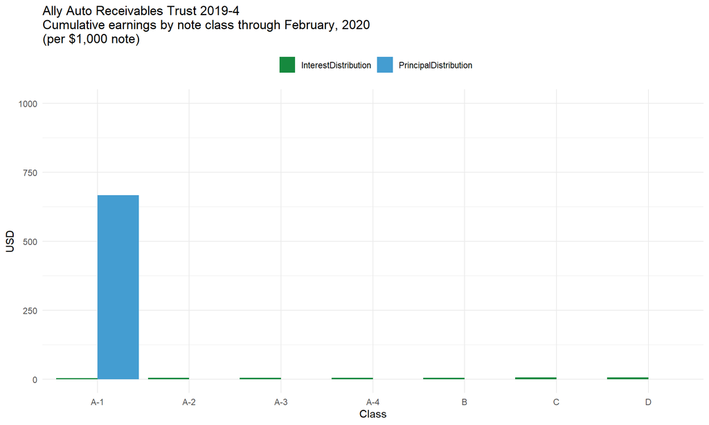

|  | deal | class | PrincipalDistribution | InterestDistribution |
| --- | --- | --- | --- | --- |
| 1 | Ally Auto Receivables Trust 2019-4 | A-1 | 667.048067896825 | 3.59107234126984 |
| 2 | Ally Auto Receivables Trust 2019-4 | A-2 | 0 | 5.03944445454546 |
| 3 | Ally Auto Receivables Trust 2019-4 | A-3 | 0 | 4.80444443452381 |
| 4 | Ally Auto Receivables Trust 2019-4 | A-4 | 0 | 5.01333328809879 |
| 5 | Ally Auto Receivables Trust 2019-4 | B | 0 | 5.58777742520399 |
| 6 | Ally Auto Receivables Trust 2019-4 | C | 0 | 6.11 |
| 7 | Ally Auto Receivables Trust 2019-4 | D | 0 | 6.76277745241581 |

##### Forecast

Forecasted principal balances are based on a forecasted total amount distributed to interest and principal balances in future terms. These values are calculated using an ETS time series forecasting model. It uses the historic values as input to create the forecasted values (see bottom chart).

Remaining note principal balances are calculated in each period by subtracting the forecasted dsitribution amount from remaining note principal balances according to note seniority. In each period, the interest distribution amount is first calculated and subtracted from the forecasted distribution amount before applying the remaining distribution amount to the note principal balances for the next period.

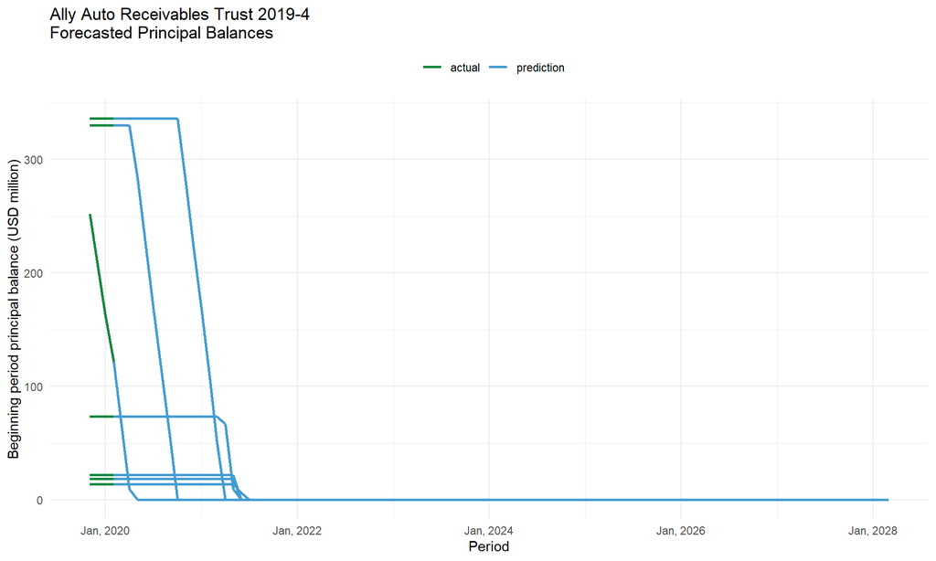

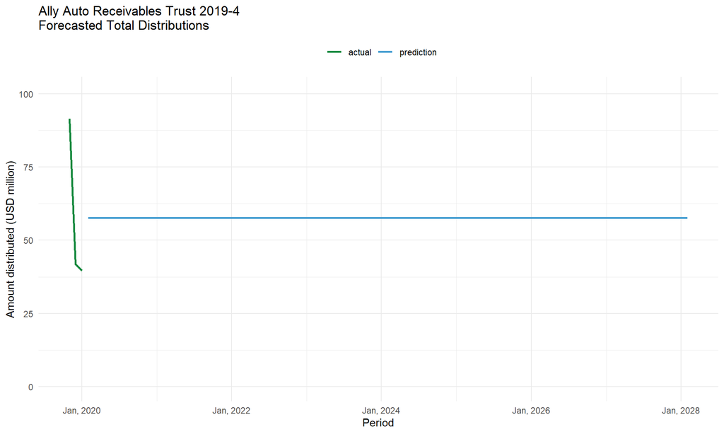

### .

*Copyright Tommy Morrison 2020*